# Elite Colleges and upward mobility

# Research Question

In this replication of the paper “Elite Colleges and upward mobility” (Zimmerman, 2019), I attempt to answer the following research question:

**Does admission to elite colleges in Chile help students outside of historically advantageous groups achieve leadership outcomes?**

# Context

Admission to universities in Chile are base on a test score. The paper conducts a Regression analysis to estimate the admission effect on leadership outcomes. Leadership outcome is defined as securing a C-Suite/Board role The premise is that students just above and just below the cutoff are similar and provide an ‘as good as random’ sample to estimate the admission effects.

# Data Preparation

## Data and Libraries

```r
library(dplyr)
library(ggplot2)
library(tidyr)
library(broom)
library(caret)
```

```r
long <- read.csv("zimmerman_long.csv")
wide <- read.csv("zimmerman_wide.csv")
sim <- read.csv("simulated_data.csv")
```

## Variable Creation

### Cutoff Score

The testscore has been normalized to have value of $0$ at the cutoff point. Checking that below.

```r
cutoff_score <- min(sim$testscore[sim$cutoff==1])
cutoff_score
```

```
## [1] 0
```

### Match to School

The author was unable to match all applicants to their high school. I create a variable caled `has_hs` which indicates whether the applicant has a high school matched.

```r
sim$has_hs <- !is.na(sim$private)
```

### Bandwidth Subsets

The author works with two bandwidths aroud the testscore cutoff (1) $\pm$ 20 (referred as BW20) and (2) $\pm$ 10 (referred as BW10).

The full dataset is already with the $\pm$ 20 range (as we shall see below), so here I create a subset that is $\pm$ 10 aroud the testscore.

Note: I run the model specifications test in the end to assess sensitivity to bandwidth specification.

```r
sim10bw <- sim %>% filter(abs(testscore)<=10)
head(sim10bw)
```

|  | X | id | female | private | testscore | cutoff | lead | has_hs |
| --- | --- | --- | --- | --- | --- | --- | --- | --- |
| 1 | 3791 | 11 | 1 | NA | 10 | 1 | 1 | FALSE |
| 2 | 3792 | 86 | 1 | NA | 10 | 1 | 1 | FALSE |
| 3 | 3793 | 112 | 1 | NA | 10 | 1 | 1 | FALSE |
| 4 | 3794 | 128 | 1 | NA | 10 | 1 | 1 | FALSE |
| 5 | 3795 | 171 | 1 | NA | 10 | 1 | 1 | FALSE |
| 6 | 3796 | 233 | 1 | NA | 10 | 1 | 0 | FALSE |

# Data Exploration

## Descriptive statistics

I generate descriptive statistics for the $\pm 20$ (BW20) and the $\pm 10$ (BW10) dataset.

```r
summary_all <- sim %>%
  summarize(
            applicants=n(),
            has_hs=sum(has_hs),
            females=mean(female),
            private=mean(private,na.rm=TRUE),
            cutoff=mean(cutoff),
            testscore_mean = mean(testscore),
            testscore_sd = sd(testscore),
            has_hs_prop = sum(has_hs)/n()) %>% t()

summary_10bw <- sim10bw %>%
  summarize(
            applicants=n(),
            has_hs=sum(has_hs),
            females=mean(female),
            private=mean(private,na.rm=TRUE),
            cutoff=mean(cutoff),
            testscore_mean = mean(testscore),
            testscore_sd = sd(testscore),
            has_hs_prop = sum(has_hs)/n()) %>% t()

summary_stats <- cbind(summary_all,summary_10bw)
colnames(summary_stats) <- c("bw20","bw10")
summary_stats
```

```
##                         bw20          bw10
## applicants     60500.0000000 32870.0000000
## has_hs         40919.0000000 22272.0000000
## females            0.3236529     0.3224217
## private            0.4767223     0.4754400
## cutoff             0.4683140     0.5022817
## testscore_mean    -1.1975868    -0.3299057
## testscore_sd      11.1246817     6.0564005
## has_hs_prop        0.6763471     0.6775783
```

- 60.5K Applicants in the bw20 set and about 32.8K applicants in the bw10 set
- About 41K applicants(67%) have a match to high school in the bw20 set, and about 22K (67%) in the bw10 set
- About 32% females in both datasets
- About 47% applicants from private schools in both datasets (conditional on match to a school)
- About 46% applicants admitted to an elite college in the bw20 set and about 50% in the bw10 set
- Test score mean goes up for bw10, and standard deviation goes down

## Missing values

About 19.5K applicants weren’t matched to their high schools, so the `private` variable is missing for them

```r
sum(is.na(sim$private))
```

```
## [1] 19581
```

```r
sum(is.na(sim$private))/nrow(sim)
```

```
## [1] 0.3236529
```

That’s about 32% of the applicants

```r
table(sim$female,is.na(sim$private))
```

```
##
##     FALSE  TRUE
##   0 40919     0
##   1     0 19581
```

Turns out all the missing private rows are females. That’s convenient because we’d be interested in the private school status of male applicants only.

# Assumptions Checks

## Balance Tests

### Proportion of females

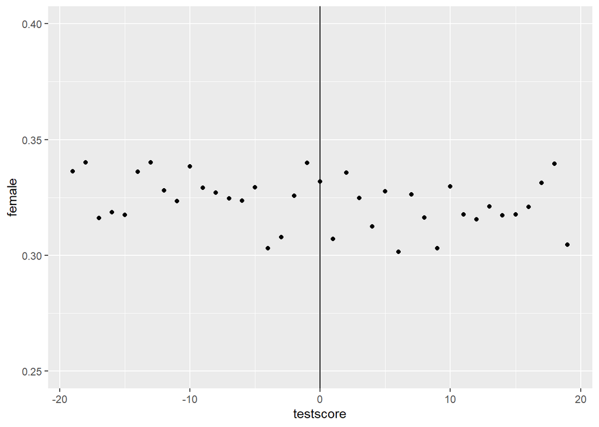

```r
sim %>% group_by(testscore) %>%
  summarize(female=mean(female)) %>%
  ggplot(aes(x=testscore,y=female))+
  geom_point()+
  ylim(0.25,0.4)+
  geom_vline(xintercept = 0)
```

Proportion of females looks balanced across both groups

### Proportion of Match to High School

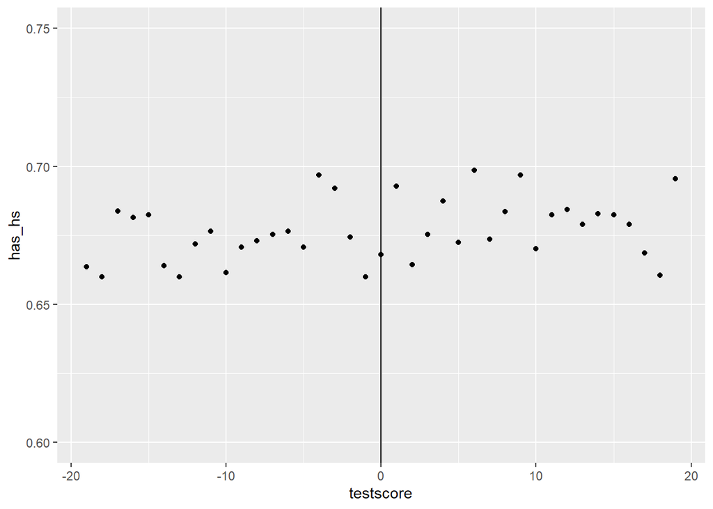

```r
sim %>% group_by(testscore) %>%
  summarize(has_hs=mean(has_hs)) %>%
  ggplot(aes(x=testscore,y=has_hs))+
  geom_point()+
  ylim(0.6,0.75)+
  geom_vline(xintercept = 0)
```

Proportion of Match to High School looks balanced across both groups

### Proportion of applicants from private schools

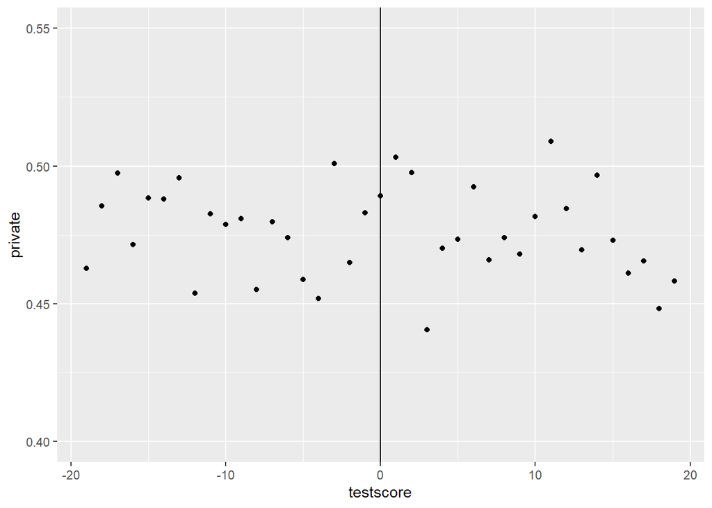

```r
sim %>% group_by(testscore) %>%
  summarize(private=mean(private,na.rm=TRUE)) %>%
  ggplot(aes(x=testscore,y=private))+
  geom_point()+
  ylim(0.4,0.55)+
  geom_vline(xintercept = 0)
```

Proportion of applicants from private schools looks balanced across both groups

### Statistical Tests

We check the mean levels of variables of interest in the two groups and conduct t.tests for difference. We do this analysis both for the BW0 set and the BW10 set.

#### On BW20

```r
balance_test <- sim %>%
  group_by(cutoff) %>%
  summarize(
    applicants=n(),
    female=sum(female),
    match_to_school=sum(!is.na(private)),
    private=sum(private,na.rm=TRUE)) %>%
  mutate(
    female_prop=female/applicants,
    match_to_school_prop = match_to_school/applicants,
    private_prop = private/match_to_school
  ) %>% select(
    female_prop,match_to_school_prop,private_prop
  ) %>% t() %>%
  round(digits = 5)

colnames(balance_test) <- c("below_cutoff","above_cutoff")
balance_test
```

```
##                      below_cutoff above_cutoff
## female_prop               0.32679      0.32009
## match_to_school_prop      0.67321      0.67991
## private_prop              0.47666      0.47680
```

The means looks similar across both groups. We do t.tests below.

```r
sim %>%
  mutate(match_to_school=!is.na(private)) %>%
  select(female,private,match_to_school,cutoff) %>%
  gather(key="variable",value="value",female:match_to_school) %>%
  group_by(variable) %>%
  do(tidy(t.test(value~cutoff,data=.))) %>%
  rename(diff_means=estimate,
         mean_below_cutoff=estimate1,
         mean_above_cutoff=estimate2) %>%
  select(diff_means,mean_below_cutoff,mean_above_cutoff,p.value)
```

| variable | diff_means | mean_below_cutoff | mean_above_cutoff | p.value |
| --- | --- | --- | --- | --- |
| female | 0.0067084223 | 0.3267945 | 0.3200861 | 0.07833744 |
| match_to_school | -0.0067084223 | 0.6732055 | 0.6799139 | 0.07833744 |
| private | -0.0001394351 | 0.4766567 | 0.4767961 | 0.97751298 |

Means are not statistically different (at 0.05% level) across groups

#### On BW10

```r
balance_test <- sim10bw %>%
  group_by(cutoff) %>%
  summarize(
    applicants=n(),
    female=sum(female),
    match_to_school=sum(!is.na(private)),
    private=sum(private,na.rm=TRUE)) %>%
  mutate(
    female_prop=female/applicants,
    match_to_school_prop = match_to_school/applicants,
    private_prop = private/match_to_school
  ) %>% select(
    female_prop,match_to_school_prop,private_prop
  ) %>% t() %>%
  round(digits = 5)

colnames(balance_test) <- c("below_cutoff","above_cutoff")
balance_test
```

```
##                      below_cutoff above_cutoff
## female_prop               0.32512      0.31975
## match_to_school_prop      0.67488      0.68025
## private_prop              0.47269      0.47814
```

The means looks similar across both groups. We do t.tests below.

```r
sim10bw %>%
  mutate(match_to_school=!is.na(private)) %>%
  select(female,private,match_to_school,cutoff) %>%
  gather(key="variable",value="value",female:match_to_school) %>%
  group_by(variable) %>%
  do(tidy(t.test(value~cutoff,data=.))) %>%
  rename(diff_means=estimate,
         mean_below_cutoff=estimate1,
         mean_above_cutoff=estimate2) %>%
  select(diff_means,mean_below_cutoff,mean_above_cutoff,p.value)
```

| variable | diff_means | mean_below_cutoff | mean_above_cutoff | p.value |
| --- | --- | --- | --- | --- |
| female | 0.005376641 | 0.3251222 | 0.3197456 | 0.2970833 |
| match_to_school | -0.005376641 | 0.6748778 | 0.6802544 | 0.2970833 |
| private | -0.005448169 | 0.4726927 | 0.4781409 | 0.4156499 |

Means are not statistically different (at 0.05% level) across groups

## Anticipation Effect

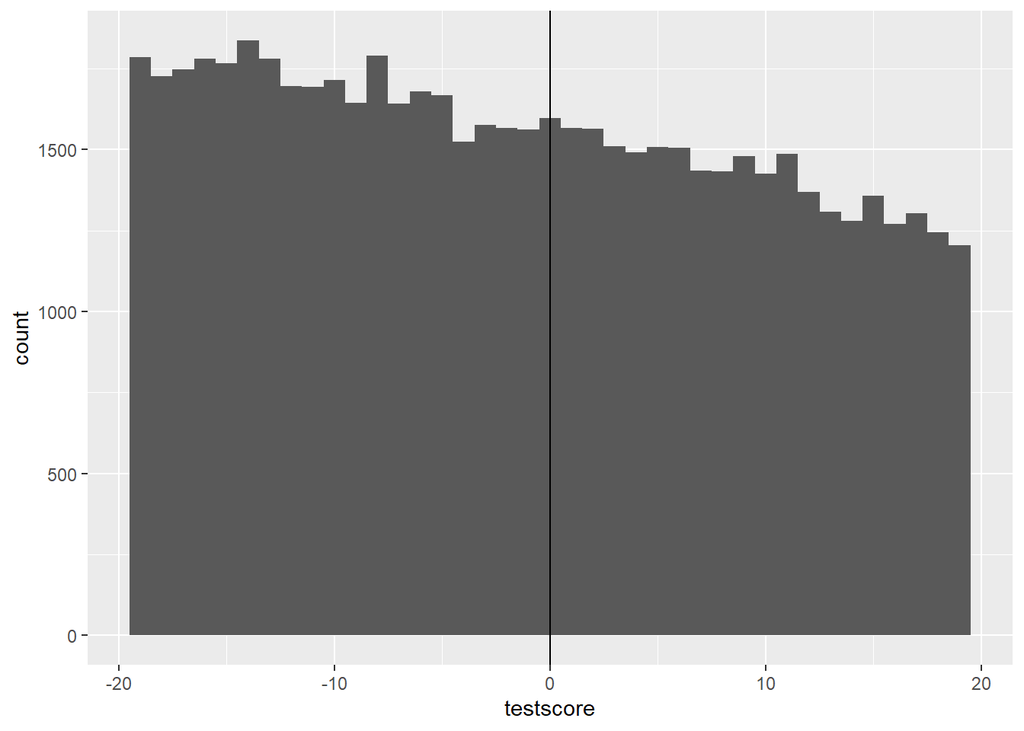

```r
ggplot(data=sim,aes(x=testscore))+
  geom_histogram(binwidth = 1)+
  geom_vline(xintercept = 0)
```

It doesn’t look like there’s any anticipation effect. There is a slight bump around the cutoff, but it doesn’t look like applicants are missing just below the cutoff, and appearing above the cutoff.

# Visualizing the Discontinuity

## Pooled (bw20)

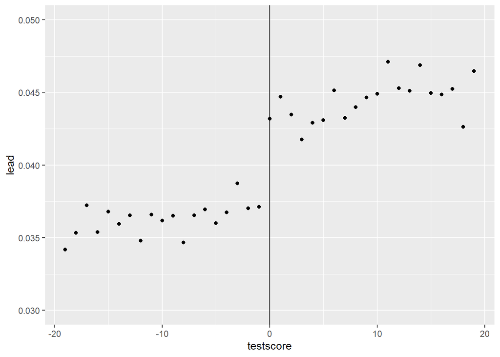

```r
sim %>% group_by(testscore) %>%
  summarize(lead=mean(lead)) %>%
  ggplot(aes(x=testscore,y=lead))+
  geom_point()+
  ylim(0.03,0.05)+
  geom_vline(xintercept = 0)
```

We see a clear discontinuity, suggesting admission effects.

## By SEC Groups (BW20)

We replicate Figure 6, Panel B from the paper below.

### Males vs Females

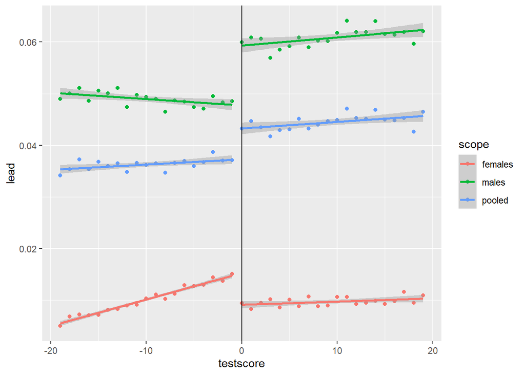

```r
females <- sim %>% filter(female==1) %>% mutate(scope="females")
males <- sim %>% filter(female==0) %>% mutate(scope="males")
all_data <- sim %>% mutate(scope="pooled")

analysis_data <- bind_rows(females,males,all_data) %>%
  group_by(cutoff,scope,testscore) %>%
  summarize(lead=mean(lead))


ggplot(data=analysis_data,aes(x=testscore,y=lead,group=interaction(scope,cutoff),color=scope))+
  geom_point()+
  geom_smooth(method = "lm")+
  geom_vline(xintercept = 0)
```

We see a positive discontinuity in the pooled and males set of points, but not in the females.

### Private vs Non-private

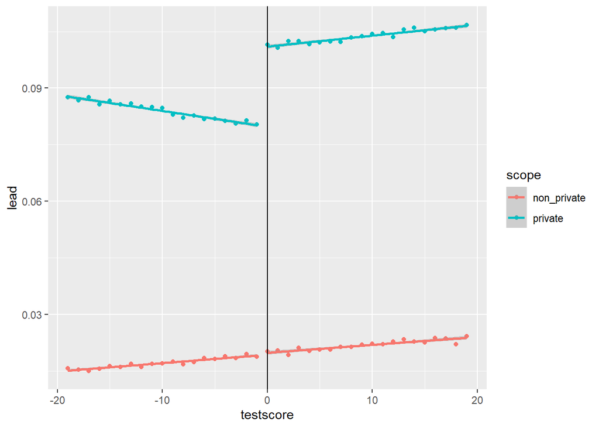

```r
private <- sim %>% filter(female==0, private==1) %>% mutate(scope="private")
non_private <- sim %>% filter(female==0, private==0) %>% mutate(scope="non_private")

analysis_data <- bind_rows(private,non_private) %>%
  group_by(cutoff,scope) %>%
  mutate(mean_group_lead=mean(lead)) %>%
  group_by(cutoff,scope,testscore) %>%
  summarize(lead=mean(lead),mean_group_lead=mean(mean_group_lead))


ggplot(data=analysis_data,aes(x=testscore,y=lead,group=interaction(scope,cutoff),color=scope))+
  geom_point()+
  geom_smooth(method = "lm")+
  geom_vline(xintercept = 0)
```

We see a positive discontinuity for applicants from private schools but not for applicants from non-private schools.

## By SEC Groups (BW10)

The paper does not visualize the data for BW10. We visualize the data based on the model specifications BW10. The author does not use a slope coefficient, so the analysis is just a comparision of means on both sides of the cutoff.

### Males vs Females

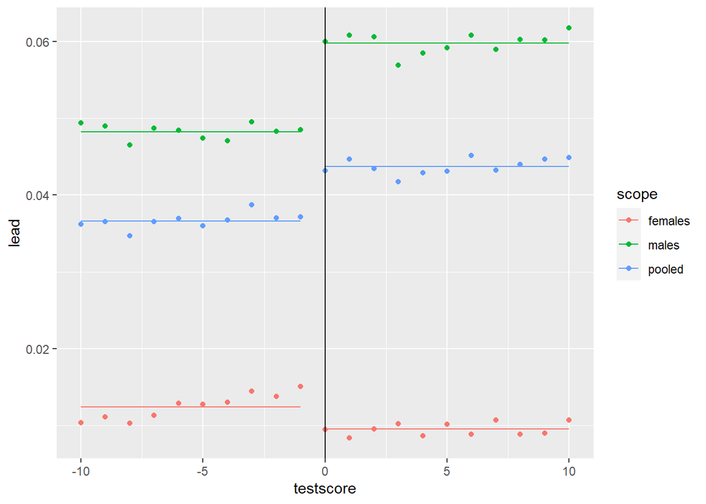

```r
females10bw <- sim10bw %>% filter(female==1) %>% mutate(scope="females")
males10bw <- sim10bw %>% filter(female==0) %>% mutate(scope="males")
all_data10bw <- sim10bw %>% mutate(scope="pooled")

analysis_data10bw <- bind_rows(females10bw,males10bw,all_data10bw) %>%
  group_by(cutoff,scope) %>%
  mutate(mean_group_lead=mean(lead)) %>%
  group_by(cutoff,scope,testscore) %>%
  summarize(lead=mean(lead),mean_group_lead=mean(mean_group_lead))


ggplot(data=analysis_data10bw,aes(x=testscore,y=lead,group=interaction(scope,cutoff),color=scope))+
  geom_point()+
  geom_line(aes(y=mean_group_lead))+
  #geom_smooth(method = "lm",formula="lead~scope")+
  # geom_hline(yintercept="mean", linetype="dashed")+
  geom_vline(xintercept = 0)
```

We see similar visuals as in BW20. Positive discontinuities can be seen for pooled and male datasets, but not for females.

### Private vs Non-private

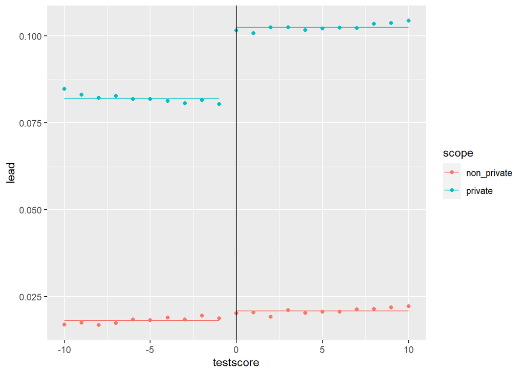

```r
private10bw <- sim10bw %>% filter(female==0, private==1) %>% mutate(scope="private")
non_private10bw <- sim10bw %>% filter(female==0, private==0) %>% mutate(scope="non_private")

analysis_data10bw <- bind_rows(private10bw,non_private10bw) %>%
  group_by(cutoff,scope) %>%
  mutate(mean_group_lead=mean(lead)) %>%
  group_by(cutoff,scope,testscore) %>%
  summarize(lead=mean(lead),mean_group_lead=mean(mean_group_lead))


ggplot(data=analysis_data10bw,aes(x=testscore,y=lead,group=interaction(scope,cutoff),color=scope))+
  geom_point()+
  geom_line(aes(y=mean_group_lead))+
  #geom_smooth(method = "lm",formula="lead~scope")+
  # geom_hline(yintercept="mean", linetype="dashed")+
  geom_vline(xintercept = 0)
```

We see similar visuals as in BW20. Positive discontinuities can be seen for applicants from private schools but, but not for applicants from non-private school.

# Regression Discontinuity Analysis

## RD with BW20 Bandwidth

### Pooled Data

```r
m1 <- lm(data=sim,lead~cutoff+testscore)
summary(m1)
```

```
##
## Call:
## lm(formula = lead ~ cutoff + testscore, data = sim)
##
## Residuals:
##      Min       1Q   Median       3Q      Max
## -0.04558 -0.04431 -0.03708 -0.03604  0.96476
##
## Coefficients:
##              Estimate Std. Error t value Pr(>|t|)
## (Intercept) 0.0374283  0.0018258  20.499   <2e-16 ***
## cutoff      0.0059628  0.0031864   1.871   0.0613 .
## testscore   0.0001153  0.0001429   0.807   0.4197
## ---
## Signif. codes:  0 '***' 0.001 '**' 0.01 '*' 0.05 '.' 0.1 ' ' 1
##
## Residual standard error: 0.1961 on 60497 degrees of freedom
## Multiple R-squared:  0.0004446,  Adjusted R-squared:  0.0004115
## F-statistic: 13.45 on 2 and 60497 DF,  p-value: 1.44e-06
```

### Male and Private Schools

```r
males_private <- lm(data=sim,lead~cutoff+testscore,subset=(female==0 & private==1))
summary(males_private)
```

```
##
## Call:
## lm(formula = lead ~ cutoff + testscore, data = sim, subset = (female ==
##     0 & private == 1))
##
## Residuals:
##      Min       1Q   Median       3Q      Max
## -0.10428 -0.10350 -0.08457 -0.08386  0.91656
##
## Coefficients:
##               Estimate Std. Error t value Pr(>|t|)
## (Intercept)  8.337e-02  4.782e-03  17.435   <2e-16 ***
## cutoff       2.092e-02  8.312e-03   2.516   0.0119 *
## testscore   -7.074e-05  3.739e-04  -0.189   0.8499
## ---
## Signif. codes:  0 '***' 0.001 '**' 0.01 '*' 0.05 '.' 0.1 ' ' 1
##
## Residual standard error: 0.2907 on 19504 degrees of freedom
## Multiple R-squared:  0.001128,   Adjusted R-squared:  0.001026
## F-statistic: 11.01 on 2 and 19504 DF,  p-value: 1.658e-05
```

### Male and Non-private

```r
male_public <- lm(data=sim,lead~cutoff+testscore,subset=(female==0 & private==0))
summary(male_public)
```

```
##
## Call:
## lm(formula = lead ~ cutoff + testscore, data = sim, subset = (female ==
##     0 & private == 0))
##
## Residuals:
##      Min       1Q   Median       3Q      Max
## -0.02386 -0.02149 -0.01879 -0.01685  0.98487
##
## Coefficients:
##              Estimate Std. Error t value Pr(>|t|)
## (Intercept) 0.0192247  0.0021438   8.968   <2e-16 ***
## cutoff      0.0005357  0.0037524   0.143    0.886
## testscore   0.0002157  0.0001682   1.282    0.200
## ---
## Signif. codes:  0 '***' 0.001 '**' 0.01 '*' 0.05 '.' 0.1 ' ' 1
##
## Residual standard error: 0.1374 on 21409 degrees of freedom
## Multiple R-squared:  0.0003682,  Adjusted R-squared:  0.0002748
## F-statistic: 3.943 on 2 and 21409 DF,  p-value: 0.01941
```

### Females

```r
females <- lm(data=sim,lead~cutoff+testscore,subset=(female==1))
summary(females)
```

```
##
## Call:
## lm(formula = lead ~ cutoff + testscore, data = sim, subset = (female ==
##     1))
##
## Residuals:
##      Min       1Q   Median       3Q      Max
## -0.01268 -0.01123 -0.00978 -0.00832  0.99293
##
## Coefficients:
##               Estimate Std. Error t value Pr(>|t|)
## (Intercept)  0.0129750  0.0016164   8.027 1.05e-15 ***
## cutoff      -0.0059043  0.0028226  -2.092   0.0365 *
## testscore    0.0002907  0.0001263   2.301   0.0214 *
## ---
## Signif. codes:  0 '***' 0.001 '**' 0.01 '*' 0.05 '.' 0.1 ' ' 1
##
## Residual standard error: 0.09878 on 19578 degrees of freedom
## Multiple R-squared:  0.0002725,  Adjusted R-squared:  0.0001703
## F-statistic: 2.668 on 2 and 19578 DF,  p-value: 0.06942
```

## RD with BW10 Bandwidth

### Pooled Data

```r
m110bw <- lm(data=sim10bw,lead~cutoff)
summary(m110bw)
```

```
##
## Call:
## lm(formula = lead ~ cutoff, data = sim10bw)
##
## Residuals:
##      Min       1Q   Median       3Q      Max
## -0.04373 -0.04373 -0.03661 -0.03661  0.96339
##
## Coefficients:
##             Estimate Std. Error t value Pr(>|t|)
## (Intercept) 0.036614   0.001535  23.848  < 2e-16 ***
## cutoff      0.007117   0.002166   3.285  0.00102 **
## ---
## Signif. codes:  0 '***' 0.001 '**' 0.01 '*' 0.05 '.' 0.1 ' ' 1
##
## Residual standard error: 0.1964 on 32868 degrees of freedom
## Multiple R-squared:  0.0003283,  Adjusted R-squared:  0.0002979
## F-statistic: 10.79 on 1 and 32868 DF,  p-value: 0.001019
```

### Male & Private

```r
males_private10bw <- lm(data=sim10bw,lead~cutoff,subset=(female==0 & private==1))
summary(males_private10bw)
```

```
##
## Call:
## lm(formula = lead ~ cutoff, data = sim10bw, subset = (female ==
##     0 & private == 1))
##
## Residuals:
##      Min       1Q   Median       3Q      Max
## -0.10242 -0.10242 -0.08201 -0.08201  0.91799
##
## Coefficients:
##             Estimate Std. Error t value Pr(>|t|)
## (Intercept) 0.082008   0.004006  20.473  < 2e-16 ***
## cutoff      0.020413   0.005625   3.629 0.000286 ***
## ---
## Signif. codes:  0 '***' 0.001 '**' 0.01 '*' 0.05 '.' 0.1 ' ' 1
##
## Residual standard error: 0.2894 on 10587 degrees of freedom
## Multiple R-squared:  0.001242,   Adjusted R-squared:  0.001148
## F-statistic: 13.17 on 1 and 10587 DF,  p-value: 0.0002859
```

### Male and Non-private

```r
male_public10bw <- lm(data=sim10bw,lead~cutoff,subset=(female==0 & private==0))
summary(male_public10bw)
```

```
##
## Call:
## lm(formula = lead ~ cutoff, data = sim10bw, subset = (female ==
##     0 & private == 0))
##
## Residuals:
##      Min       1Q   Median       3Q      Max
## -0.02082 -0.02082 -0.01804 -0.01804  0.98196
##
## Coefficients:
##             Estimate Std. Error t value Pr(>|t|)
## (Intercept) 0.018035   0.001809   9.969   <2e-16 ***
## cutoff      0.002781   0.002554   1.089    0.276
## ---
## Signif. codes:  0 '***' 0.001 '**' 0.01 '*' 0.05 '.' 0.1 ' ' 1
##
## Residual standard error: 0.138 on 11681 degrees of freedom
## Multiple R-squared:  0.0001014,  Adjusted R-squared:  1.585e-05
## F-statistic: 1.185 on 1 and 11681 DF,  p-value: 0.2763
```

### Females

```r
females10bw <- lm(data=sim10bw,lead~cutoff,subset=(female==1))
summary(females10bw)
```

```
##
## Call:
## lm(formula = lead ~ cutoff, data = sim10bw, subset = (female ==
##     1))
##
## Residuals:
##      Min       1Q   Median       3Q      Max
## -0.01241 -0.01241 -0.00947 -0.00947  0.99053
##
## Coefficients:
##              Estimate Std. Error t value Pr(>|t|)
## (Intercept)  0.012408   0.001427   8.698   <2e-16 ***
## cutoff      -0.002937   0.002021  -1.453    0.146
## ---
## Signif. codes:  0 '***' 0.001 '**' 0.01 '*' 0.05 '.' 0.1 ' ' 1
##
## Residual standard error: 0.104 on 10596 degrees of freedom
## Multiple R-squared:  0.0001992,  Adjusted R-squared:  0.0001048
## F-statistic: 2.111 on 1 and 10596 DF,  p-value: 0.1463
```

# Results Summary

```r
get_model_coefficients <- function(rd_model){
  model_result <- tidy(rd_model) %>% filter(term=="cutoff") %>% select(estimate,std.error,p.value)
  model_result
}

rd_models <- list(
  #BW20
  m1,males_private,male_public,females,
  #BW10
  m110bw,males_private10bw,male_public10bw,females10bw
  )

model_results_df <- bind_rows(lapply(rd_models,get_model_coefficients))

model_results_df$model_name <- c(
  #BW20
  "Pooled (BW20)","Male & Private (BW20)", "Male & Non-Private (BW20)", "Female (BW20)",
  #BW10
    "Pooled (BW10)","Male & Private (BW10)", "Male & Non-Private (BW10)", "Female (BW10)"

)

model_results_df <- model_results_df %>%
  select(model_name,everything()) %>%
  mutate(signi_0.05=if_else(p.value<0.05,"Significant at 0.05 level","Not Significant at 0.05 level"))


model_results_df
```

| model_name | estimate | std.error | p.value | signi_0.05 |
| --- | --- | --- | --- | --- |
| Pooled (BW20) | 0.0059627946 | 0.003186385 | 0.061303437 | Not Significant at 0.05 level |
| Male & Private (BW20) | 0.0209155660 | 0.008312432 | 0.011871459 | Significant at 0.05 level |
| Male & Non-Private (BW20) | 0.0005356895 | 0.003752383 | 0.886481236 | Not Significant at 0.05 level |
| Female (BW20) | -0.0059042518 | 0.002822570 | 0.036469291 | Significant at 0.05 level |
| Pooled (BW10) | 0.0071173801 | 0.002166312 | 0.001019146 | Significant at 0.05 level |
| Male & Private (BW10) | 0.0204128091 | 0.005624922 | 0.000285868 | Significant at 0.05 level |
| Male & Non-Private (BW10) | 0.0027805210 | 0.002554144 | 0.276339044 | Not Significant at 0.05 level |
| Female (BW10) | -0.0029368566 | 0.002021371 | 0.146280200 | Not Significant at 0.05 level |

For the BW20, we see a similar result - positive and statistically significant admission effects for Male and Private applicants only. However, we also see negative and statistically significant admission effects for females in this specification.

# Model Specification Tests

The paper uses k-fold cross-validation to identify the most appropriate model specification by calculating the CV MSE for k=500. We use k=10 for faster computation and use RMSE as the evaluation metric.

```r
cv_rmse20bw <- numeric(4)
for(i in 0:3){
  train_control <- trainControl(method='cv',number=10)
  if(i==0){
      f <- bquote(lead ~ cutoff)
  }else{
    f <- bquote(lead ~ cutoff+poly(testscore, .(i)))

  }
  models <- train(as.formula(f), data = sim10bw, trControl=train_control, method='lm')
  cv_rmse20bw[i+1] <- (models$results$RMSE)
}
```

CV for BW10 below:

```r
cv_rmse10bw <- numeric(4)
for(i in 0:3){
  train_control <- trainControl(method='cv',number=10)
  if(i==0){
      f <- bquote(lead ~ cutoff)
  }else{
    f <- bquote(lead ~ cutoff+poly(testscore, .(i)))

  }
  models <- train(as.formula(f), data = sim10bw, trControl=train_control, method='lm')
  cv_rmse10bw[i+1] <- (models$results$RMSE)
}
```

```r
cv_results <- data.frame(
  model_speficiation=c(outer(paste("Degree", 0:3),c(" (BW20)", " (BW10)"), FUN=paste0)),
  rmse=c(cv_rmse20bw,cv_rmse10bw)
)
cv_results
```

| model_speficiation | rmse |
| --- | --- |
| Degree 0 (BW20) | 0.1962114 |
| Degree 1 (BW20) | 0.1963270 |
| Degree 2 (BW20) | 0.1962805 |
| Degree 3 (BW20) | 0.1961591 |
| Degree 0 (BW10) | 0.1962339 |
| Degree 1 (BW10) | 0.1962102 |
| Degree 2 (BW10) | 0.1961627 |
| Degree 3 (BW10) | 0.1963196 |